# Pathway ‘separation’

**J. Taroni 2018**

We’ve noted that pathways or genesets that are similar to one another, such as cell types of the myeloid lineage (e.g., neutrophils and monocytes/macrophages), can tend to get “lumped together” in PLIER models trained on training sets with smaller sample sizes or less relevant biological contexts. In contrast, the MultiPLIER model (~37K samples) tends to “separate” similar pathways into different latent variables. (See `06-sle-wb_cell_type` and `07-sle_cell_type_recount2_model`.)

**Here, we’re interested in the notion of “pathway separation” when different datasets are used for training.**

We’ll group related pathways/genesets into pathway sets. For instance, we’ll group monocyte- and macrophage-related gene sets such as `SVM Monocytes` and `DMAP_MONO2` into a “monocyte-related pathway set.”

We define **pathway separation** as the following:

- For each pathway set, at least one latent variable is significantly associated (`FDR < 0.05`) with a pathway in that set. We consider capturing *only one pathway set* to be insufficient for this evaluation. In essence, we want to make sure each set of pathways is represented in or captured by the model.
- Each pathway set is *uniquely* and significantly associated with at least one latent variable. In the neutrophil vs. monocyte/macrophage example, it’s not sufficient to have a neutrophil-associated latent variable and a latent variable associated with both neutrophils and monocytes/macrophages; we also want the monocyte/macrophage set to be captured in a latent variable that is *not also associated* with the neutrophil set.

## Set up

```r
library(ComplexHeatmap)
```

### Functions

```r
`%>%` <- dplyr::`%>%`
```

#### Custom function for detecting pathway separation

```r
CheckPathwaySeparation <- function(plier.model, pathway.set1, pathway.set2,
                                   fdr.cutoff = 0.05) {
  # Given PLIER model and two sets of pathways, check if the model is able
  # to "separate" them -- i.e., does an LV exist that is significantly
  # associated with pathways in one set BUT NOT the other set -- and return
  # a logical
  #
  # Args:
  #  plier.model: the output list from PLIER::PLIER
  #  pathway.set1: a character vector of one set of related pathways
  #  pathway.set2: a character vector of the other set of related pathways
  #  fdr.cutoff: what value should serve as the threshold for the "significant"
  #              associations? 0.05 by default
  #
  # Returns:
  #   A logical constant (TRUE or FALSE) that indicates whether or not the
  #   conditions for pathway separation have been met for pathway.set1 and
  #   pathway.set2
  #

  # takes a vector of pathway names and the data.frame that only includes
  # significant associations between pathways and LVs (summary data.frame
  # from PLIER::PLIER)
  GetAssociatedLVs <- function(set.of.pathways, filtered.df) {
    # this collapsing step will not be problematic if there is
    search.pattern <- paste(set.of.pathways, collapse = "|")
    search.index <- grep(search.pattern, filtered.df$pathway)
    associated.lvs <- unique(filtered.df$`LV index`[search.index])
  }

  # magrittr pipe
  `%>%` <- dplyr::`%>%`

  # filter the summary data.frame output from PLIER::PLIER to only associations
  # that meet the fdr.cutoff threshold
  sig.summary.df <- plier.model$summary %>%
    dplyr::filter(FDR < fdr.cutoff)

  # which LVs are associated with set 1?
  lvs.set1 <- GetAssociatedLVs(set.of.pathways = pathway.set1,
                               filtered.df = sig.summary.df)

  # which LVs are associated with set 2?
  lvs.set2 <- GetAssociatedLVs(set.of.pathways = pathway.set2,
                               filtered.df = sig.summary.df)

  # are both sets of pathways captured?
  captured <- all(c(length(lvs.set1) > 0, length(lvs.set2) > 0))
  # if not, this doesn't qualify as separation
  if (!captured) {
    return(FALSE)
  } else {
    # is there at least one latent variable that is only associated with
    # that set -- for both sets
    set1.unique <- length(setdiff(lvs.set1, lvs.set2)) > 0
    set2.unique <- length(setdiff(lvs.set2, lvs.set1)) > 0
    # if so, return TRUE
    return(all(set1.unique, set2.unique))
  }
}
```

### Files

#### Directory setup

```r
# plot and result directory setup for this notebook
plot.dir <- file.path("plots", "32")
dir.create(plot.dir, recursive = TRUE, showWarnings = FALSE)
results.dir <- file.path("results", "32")
dir.create(results.dir, recursive = TRUE, showWarnings = FALSE)
```

All subsampling and biological context models we will be evaluating are in `models/`

```r
models.dir <- "models"
```

#### Input

Models from the conditions being tested: sample size and biological context

```r
# models with different sample sizes -- "subsampled" is in the RDS object
# file names
size.model.files <- list.files(models.dir, pattern = "subsampled",
                               full.names = TRUE)
size.model.files
```

```
[1] "models/subsampled_recount2_PLIER_model_1000.RDS"  "models/subsampled_recount2_PLIER_model_16000.RDS"
[3] "models/subsampled_recount2_PLIER_model_2000.RDS"  "models/subsampled_recount2_PLIER_model_32000.RDS"
[5] "models/subsampled_recount2_PLIER_model_4000.RDS"  "models/subsampled_recount2_PLIER_model_500.RDS"
[7] "models/subsampled_recount2_PLIER_model_8000.RDS"
```

```r
# models for different biological contexts -- "accessions" is in the RDS object
# file names
context.model.files <- list.files(models.dir, pattern = "accessions",
                                  full.names = TRUE)
context.model.files
```

```
[1] "models/recount2_blood_accessions_PLIER_model.RDS"         "models/recount2_cancer_accessions_PLIER_model.RDS"
[3] "models/recount2_cell_line_accessions_PLIER_model.RDS"     "models/recount2_other_tissues_accessions_PLIER_model.RDS"
[5] "models/recount2_tissue_accessions_PLIER_model.RDS"
```

Also want the MultiPLIER / full `recount2` model

```r
recount2.model.file <- file.path("data", "recount2_PLIER_data",
                                 "recount_PLIER_model.RDS")
```

## Sets of pathways for pathway separation

#### Type I and type II interferon

Interferon (IFN)

```r
ifn.alpha.set <- c("REACTOME_INTERFERON_ALPHA_BETA_SIGNALING")
ifn.gamma.set <- c("REACTOME_INTERFERON_GAMMA_SIGNALING")
```

#### Myeloid lineage

```r
neutrophil.set <- c("DMAP_GRAN3", "IRIS_Neutrophil-Resting", "SVM Neutrophils")
monocyte.set <- c("IRIS_Monocyte-Day0", "IRIS_Monocyte-Day1",
                  "IRIS_Monocyte-Day7", "DMAP_MONO2", "SVM Monocytes",
                  "SVM Macrophages M0", "SVM Macrophages M1",
                  "SVM Macrophages M2")
```

#### Proliferation

Molecular processes we would associate with proliferating cells, namely the G1 and G2 phases of the cell cycle.

```r
g1.set <- c("REACTOME_G1_S_TRANSITION", "REACTOME_M_G1_TRANSITION",
            "REACTOME_APC_C_CDH1_MEDIATED_DEGRADATION_OF_CDC20_AND_OTHER_APC_C_CDH1_TARGETED_PROTEINS_IN_LATE_MITOSIS_EARLY_G1",
            "REACTOME_CYCLIN_E_ASSOCIATED_EVENTS_DURING_G1_S_TRANSITION_",
            "REACTOME_G1_PHASE", "REACTOME_MITOTIC_M_M_G1_PHASES",
            "REACTOME_P53_DEPENDENT_G1_DNA_DAMAGE_RESPONSE",
            "REACTOME_MITOTIC_G1_G1_S_PHASES",
            "REACTOME_P53_INDEPENDENT_G1_S_DNA_DAMAGE_CHECKPOINT")
g2.set <- c("REACTOME_MITOTIC_G2_G2_M_PHASES", "REACTOME_G2_M_CHECKPOINTS")
```

#### Wrapper functions

These are wrapper functions that are not intended to be used outside of the context of this notebook, i.e., we expect `ifn.alpha.set`, etc. to be in the global environment and we’ve essentially hard-coded this to use `FDR < 0.05`.

```r
# check pathway separation of all pairs of pathways -- IFN, myeloid,
# 'proliferation'
AllPairs <- function(plier.model) {
  ifn.results <- CheckPathwaySeparation(plier.model = plier.model,
                                        pathway.set1 = ifn.alpha.set,
                                        pathway.set2 = ifn.gamma.set)
  myeloid.results <- CheckPathwaySeparation(plier.model = plier.model,
                                        pathway.set1 = neutrophil.set,
                                        pathway.set2 = monocyte.set)
  proliferation.results <-
    CheckPathwaySeparation(plier.model = plier.model,
                           pathway.set1 = g1.set,
                           pathway.set2 = g2.set)
  return(list(IFN = ifn.results, MYELOID = myeloid.results,
              PROLIFERATION = proliferation.results))
}
```

```r
# this is specifically designed for RDS files that are the output from
# scripts/subsampling_PLIER.R (e.g., have repeats, elements named PLIER)
GetAllPairsDataFrame <- function(model.files, id.name) {
  # Given a named vector of filenames, get a data.frame of AllPairs results
  #
  # Args:
  #   model.files: named vector of filenames
  #   id.name: what should the colname of the identifier be (e.g.,
  #            "sample_size")
  #
  # Returns:
  #   A data.frame of AllPairs results

  # no names? get outta here
  if(is.null(names(model.files))) {
    stop("model.files must be a named vector!")
  }

  # for each file, read in the RDS (output of scripts/subsampling_PLIER.R) and
  # run AllPairs
  results.list <- lapply(model.files,
                         function(x) {
                           # read in the list of 5 models
                           models.list <- readRDS(x)
                           lapply(models.list,
                                  function(y) {
                                    # we need to specifically extract the
                                    # `PLIER` element of the list and test all
                                    # pairof pathways
                                    AllPairs(plier.model = y$PLIER)
                                  })
                         })

  # melt and bind the AllPairs pathway separation results, using the identifier
  # supplied as id.name
  results.df <- dplyr::bind_rows(lapply(results.list, reshape2::melt),
                                 .id = id.name)
  colnames(results.df)[3:4] <- c("pathway", "seed")

  # return the results data.frame
  return(results.df)

}
```

```r
# given the output of AllPairsDataFrame, get it suitable shape for heatmaps
WrangleForHeatmap <- function(results.df, group.colname, group.order) {
  wrangled.df <- results.df %>%
    # for each group, pathway pair
    dplyr::group_by(!!rlang::sym(group.colname), pathway) %>%
    # count how many models where there's separation
    dplyr::summarize(model_count = sum(value)) %>%
    # spread the columns
    tidyr::spread(!!rlang::sym(group.colname), model_count) %>%
    # reorder using the vector of "levels" from group.order
    dplyr::select(c("pathway", group.order)) %>%
    # the pathway names should be rownames rather than an
    # individual column
    tibble::column_to_rownames("pathway") %>%
    as.data.frame()
}
```

## Sample size

Evaluations for the effect of sample size of pathway separation, with the following sample sizes: `500`, `1000`, `2000`, `4000`, `8000`, `16000`, `32000` We performed 5 repeats with different random seeds (see `29-train_models_different_sample_size.sh` and `scripts/subsampling_PLIER.R`).

```r
# we can derive useful names from the names of the model files
# themselves
names(size.model.files) <- sub(".RDS", "", sub(".*[_]", "", size.model.files))
# detect pathway separation
size.results.df <- GetAllPairsDataFrame(size.model.files,
                                        id.name = "sample_size")
```

We’re going to represent this as a heatmap, so we’ll need to wrangle the results into a `data.frame` that looks like this

[output not shown]

Where we’re counting how many of the 5 models (repeats) the pairs of pathways are separated.

We’ve written `WrangleForHeatmap` (see above) for this purpose.

```r
size.df <- WrangleForHeatmap(results.df = size.results.df,
                             group.colname = "sample_size",
                             group.order = c("500", "1000", "2000", "4000",
                                             "8000", "16000", "32000"))
```

```
Setting row names on a tibble is deprecated.
```

```r
# let's take a look at the resulting data.frame
size.df
```

|  | 500 | 1000 | 2000 | 4000 | 8000 | 16000 | 32000 |
| --- | --- | --- | --- | --- | --- | --- | --- |
| IFN | 1 | 1 | 0 | 3 | 4 | 5 | 5 |
| MYELOID | 0 | 1 | 1 | 5 | 5 | 4 | 5 |
| PROLIFERATION | 0 | 0 | 0 | 2 | 1 | 1 | 0 |

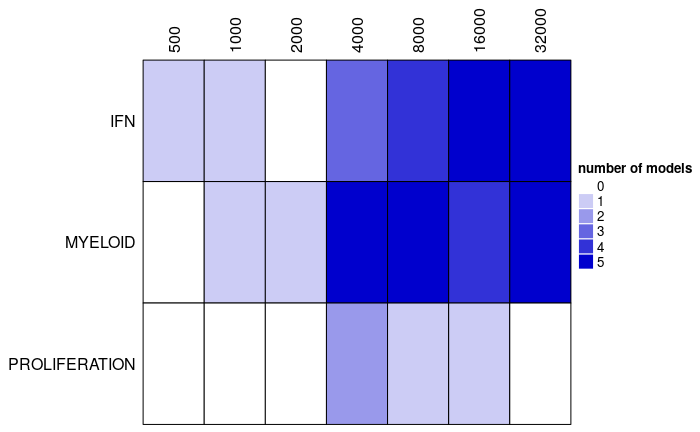

```r
size.heatmap <-
  ComplexHeatmap::Heatmap(as.matrix(size.df),
                          cluster_rows = FALSE,
                          cluster_columns = FALSE,
                          row_names_side = "left",
                          column_names_side = "top",
                          col = colorRampPalette(c("white", "blue3"))(6),
                          rect_gp = grid::gpar(col = "black"),
                          show_heatmap_legend = TRUE,
                          name = "number of models")
size.heatmap
```

## Biological context

```r
names(context.model.files) <-
  stringr::str_match(context.model.files, "recount2_(.*?)_accessions")[, 2]
# detect for pathway separation
context.results.df <- GetAllPairsDataFrame(context.model.files,
                                           id.name = "biological_context")
```

Wrangle data for heatmap

```r
context.df <- WrangleForHeatmap(results.df = context.results.df,
                                group.colname = "biological_context",
                                group.order = c("blood", "cancer", "tissue",
                                                "cell_line", "other_tissues"))
```

```
Setting row names on a tibble is deprecated.
```

```r
context.heatmap <-
  ComplexHeatmap::Heatmap(as.matrix(context.df),
                          cluster_rows = FALSE,
                          cluster_columns = FALSE,
                          row_names_side = "left",
                          column_names_side = "top",
                          col = colorRampPalette(c("white", "blue3"))(6),
                          rect_gp = grid::gpar(col = "black"),
                          show_heatmap_legend = FALSE,
                          name = "number of models",
                          show_row_names = FALSE)
```

## MultiPLIER

Now repeat this with the full model.

```r
# read in the model
multiplier.model <- readRDS(recount2.model.file)
# check all pairs for separation
multiplier.results <- AllPairs(plier.model = multiplier.model)
# there's only one model -- so this is a binary outcome!
multiplier.df <- reshape2::melt(multiplier.results) %>%  # melt the results
  # the variable name is pathway
  dplyr::mutate(pathway = L1,
                MultiPLIER = as.integer(value)) %>%
  dplyr::select(c("pathway", "MultiPLIER")) %>%
  tibble::column_to_rownames("pathway") %>%
  as.data.frame()
```

Heatmap itself

```r
multiplier.heatmap <-
  ComplexHeatmap::Heatmap(as.matrix(multiplier.df),
                          cluster_rows = FALSE,
                          cluster_columns = FALSE,
                          column_names_side = "top",
                          col = "blue4",
                          rect_gp = grid::gpar(col = "black"),
                          name = "pathway separation",
                          show_heatmap_legend = TRUE,
                          show_row_names = FALSE)
```

## Final plotting

```r
heatmap.list <- size.heatmap + context.heatmap + multiplier.heatmap
```

```
Heatmap/row annotation names are duplicated: number of modelsHeatmap/row annotation names are duplicated: number of models
```

```r
pdf(file.path(plot.dir, "multiplier_separation.pdf"))
ComplexHeatmap::draw(heatmap.list)
dev.off()
```